# advertising

#### histograms

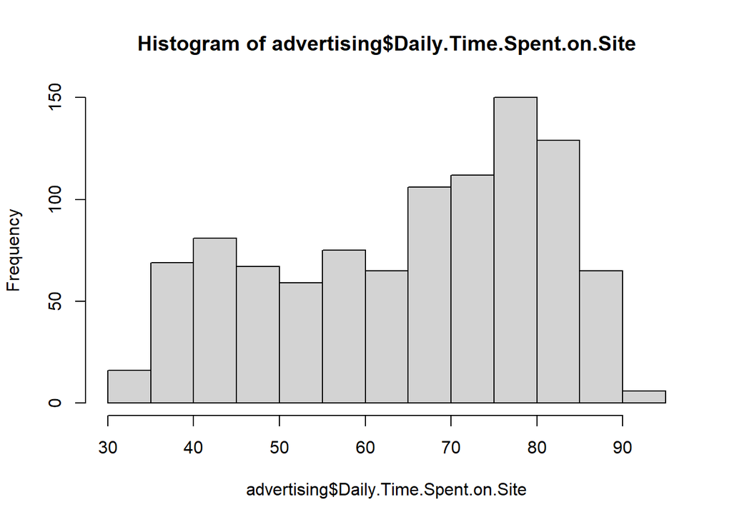

```r
hist(advertising$Daily.Time.Spent.on.Site)
```

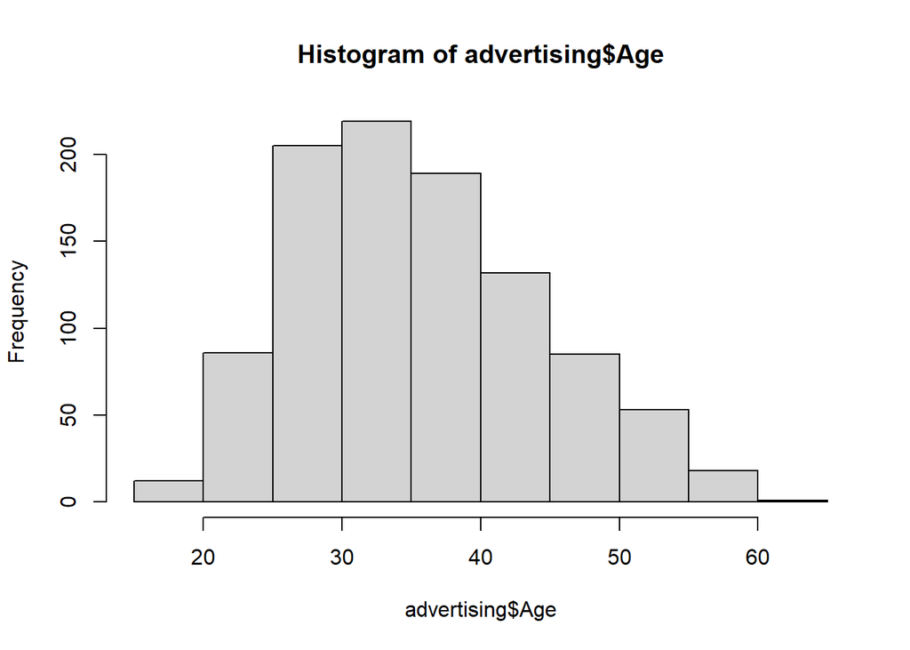

```r
hist(advertising$Age)
```

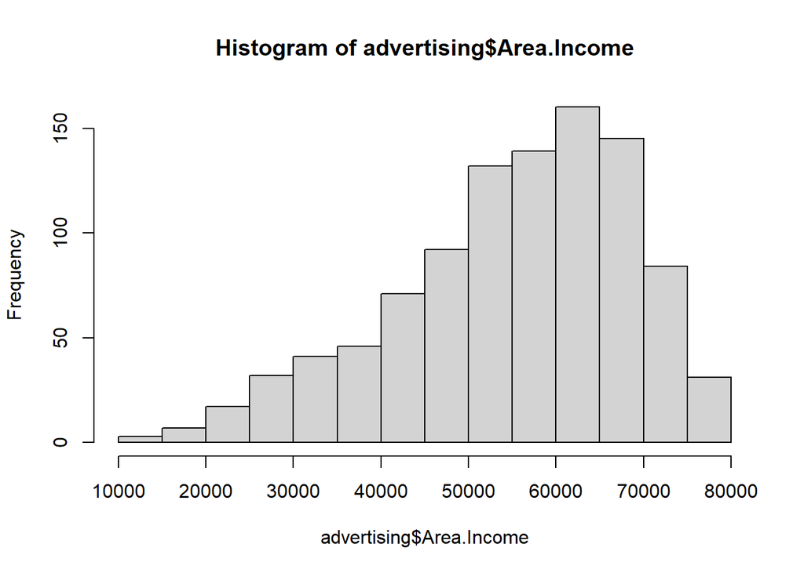

```r
hist(advertising$Area.Income)
```

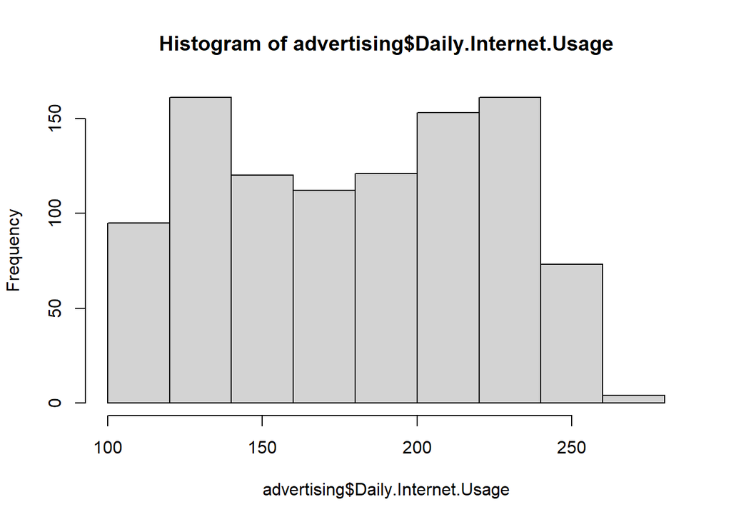

```r
hist(advertising$Daily.Internet.Usage)
```

## bivariate analysis

### covariance

```r
age_cov <- advertising$Age
ai_cov <- advertising$Area.Income
cov(age_cov, ai_cov)
```

```
## [1] -21520.93
```

covariance between age and area income represents a negative linear relationship between the two

```r
dstot_cov <- advertising$Daily.Time.Spent.on.Site
cov(age_cov, dstot_cov)
```

```
## [1] -46.17415
```

the covariance of age and daily time spent on site indicates a negative linear relationship between the two factors

```r
cov(dstot_cov, ai_cov)
```

```
## [1] 66130.81
```

the covariance of daily time spent on site and area income shows a positive linear relationship between the two.

### correlation

```r
age_corr <- advertising$Age
dstot_corr <- advertising$Daily.Time.Spent.on.Site
ai_corr <- advertising$Area.Income

cor(age_corr, dstot_corr)
```

```
## [1] -0.3315133
```

the correlation co-efficient between age and daily time spent on site is less than 0, indicating that the two factors have a negative linear relationship

```r
cor(age_corr, ai_corr)
```

```
## [1] -0.182605
```

the correlation coefficient between age and area income is less than 0, indicating that they have a negative linear relationship

```r
cor(ai_corr, dstot_corr)
```

```
## [1] 0.3109544
```

the correlation coefficient between area income and daily time spent on site is slightly above 0, showing a weak positive linear relationship

```r
cor(advertising[sapply(advertising,is.numeric)])
```

```
##                          Daily.Time.Spent.on.Site         Age  Area.Income
## Daily.Time.Spent.on.Site               1.00000000 -0.33151334  0.310954413
## Age                                   -0.33151334  1.00000000 -0.182604955
## Area.Income                            0.31095441 -0.18260496  1.000000000
## Daily.Internet.Usage                   0.51865848 -0.36720856  0.337495533
## Male                                  -0.01895085 -0.02104406  0.001322359
## Clicked.on.Ad                         -0.74811656  0.49253127 -0.476254628
##                          Daily.Internet.Usage         Male Clicked.on.Ad
## Daily.Time.Spent.on.Site           0.51865848 -0.018950855   -0.74811656
## Age                               -0.36720856 -0.021044064    0.49253127
## Area.Income                        0.33749553  0.001322359   -0.47625463
## Daily.Internet.Usage               1.00000000  0.028012326   -0.78653918
## Male                               0.02801233  1.000000000   -0.03802747
## Clicked.on.Ad                     -0.78653918 -0.038027466    1.00000000
```

### scatter plots

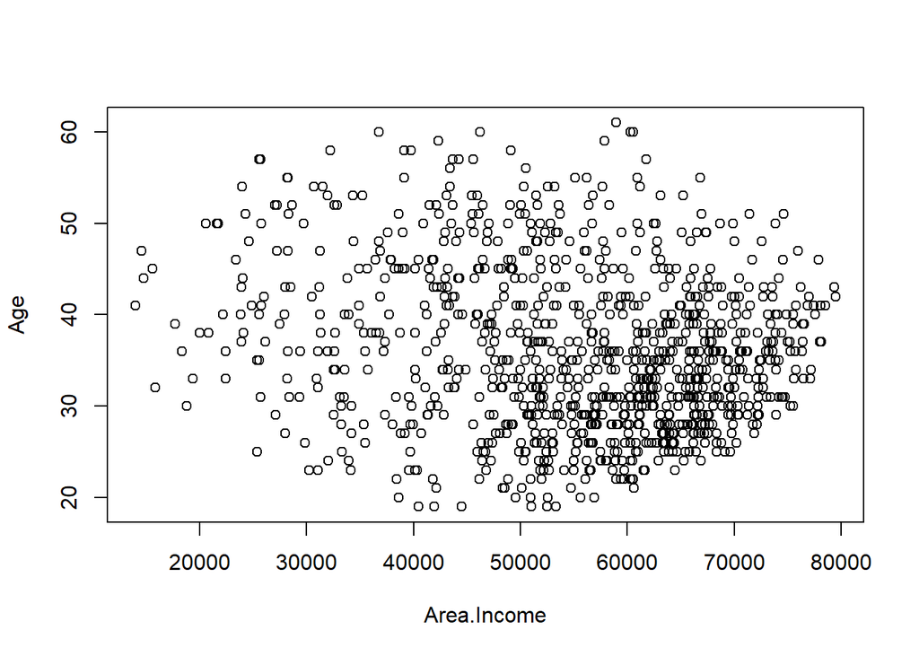

```r
ai_plot <- advertising$Area.Income
age_plot <- advertising$Age
dstot_plot <- advertising$Daily.Time.Spent.on.Site
diu_plot <- advertising$Daily.Internet.Usage

plot(ai_plot, age_plot, xlab="Area.Income", ylab="Age")
```

the under 40s seem to earn more in the 50,000-70,000 range

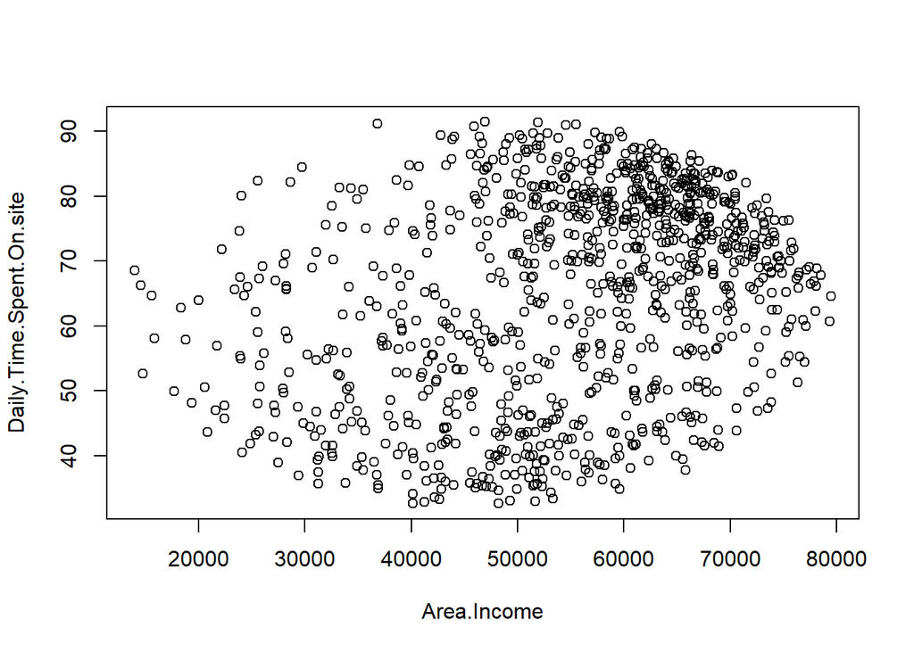

```r
#scatter plot for daily time spent on site vs income
plot(ai_plot, dstot_plot, xlab="Area.Income", ylab="Daily.Time.Spent.On.site")
```

the scatter plot indicates that those that earn more spend more time on site

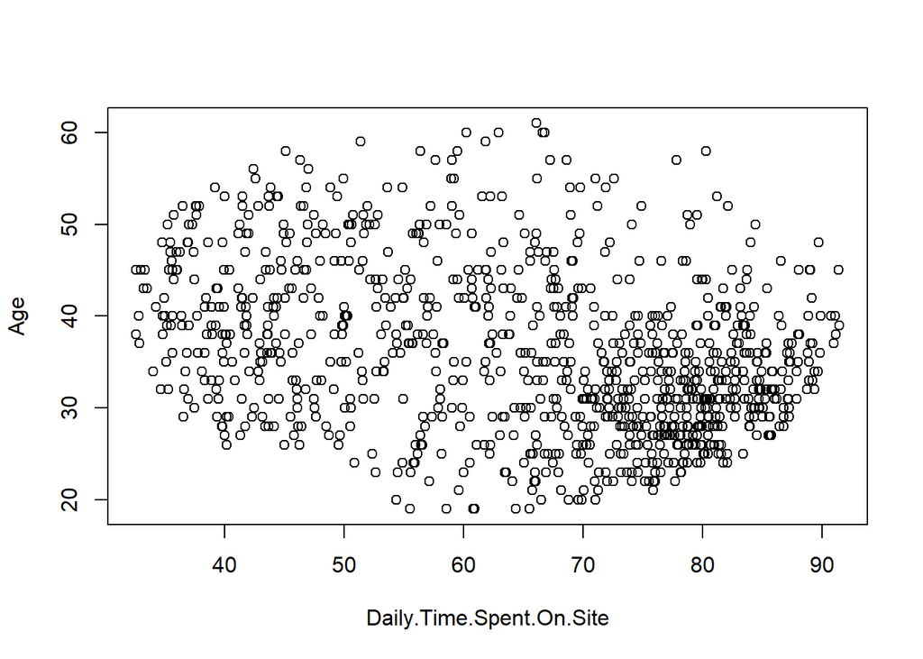

```r
#scatter plot for daily time on site vs their age
plot(dstot_plot, age_plot, xlab="Daily.Time.Spent.On.Site", ylab="Age")
```

the under 40s spend more time on site

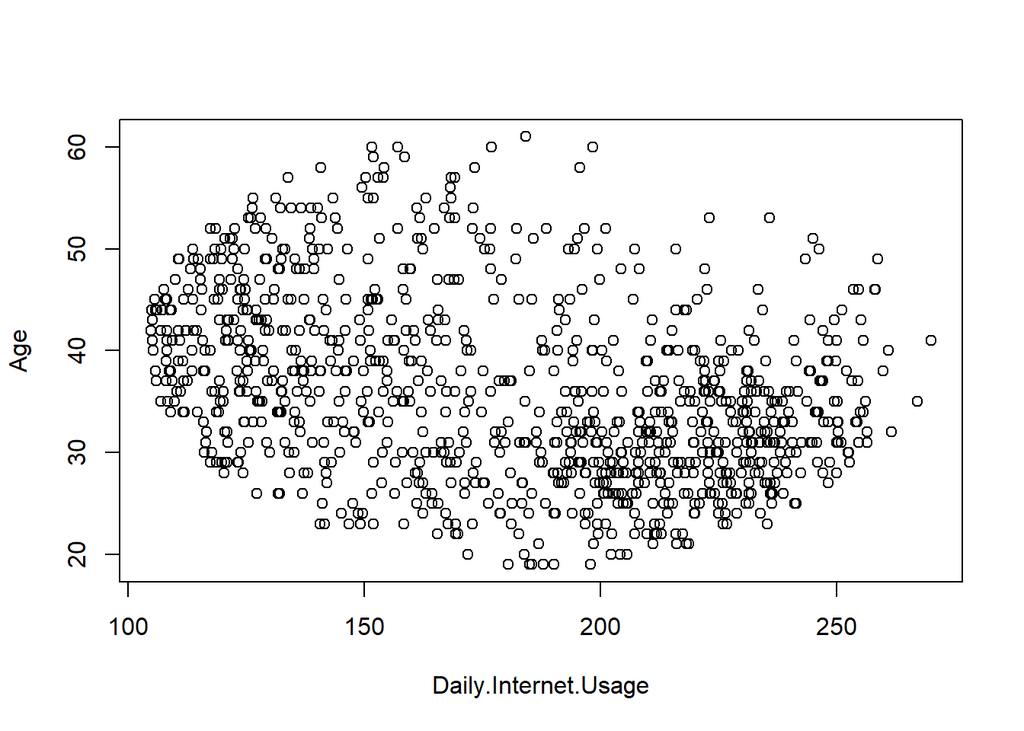

```r
plot(diu_plot, age_plot, xlab="Daily.Internet.Usage", ylab="Age")
```